# Practicum I / Part B

DA5030 / Forecasting

Daware, Aditya

Spring 25

## Loading the CSV file

```r
url.f <- "https://s3.us-east-2.amazonaws.com/artificium.us/datasets/WaterUsage-02-22-to-11-24.csv"
df.f <- read.csv(url.f, stringsAsFactors = F)
df.f <- df.f[rev(rownames(df.f)), ]
```

The CSV file is loaded and stored in the variable ‘df.f’.

## Data exploration

```r
library(knitr)
kable(head(df.f))
```

|  | Month | Year | Volume.In.Thousands.Liters | Days.in.Cycle | Avg.Daily.Water.Use.in.Liters |
| --- | --- | --- | --- | --- | --- |
| 34 | 2 | 2022 | 39 | 29 | 1345 |
| 33 | 3 | 2022 | 13 | 28 | 464 |
| 32 | 4 | 2022 | 26 | 33 | 788 |
| 31 | 5 | 2022 | 34 | 30 | 1133 |
| 30 | 6 | 2022 | 18 | 31 | 581 |
| 29 | 7 | 2022 | 21 | 30 | 700 |

```r
str(df.f)
```

```
## 'data.frame':    34 obs. of  5 variables:
##  $ Month                        : int  2 3 4 5 6 7 8 9 10 11 ...
##  $ Year                         : int  2022 2022 2022 2022 2022 2022 2022 2022 2022 2022 ...
##  $ Volume.In.Thousands.Liters   : int  39 13 26 34 18 21 28 25 11 28 ...
##  $ Days.in.Cycle                : int  29 28 33 30 31 30 30 32 30 29 ...
##  $ Avg.Daily.Water.Use.in.Liters: int  1345 464 788 1133 581 700 933 781 367 966 ...
```

```r
summary(df.f)
```

```
##      Month           Year      Volume.In.Thousands.Liters Days.in.Cycle
##  Min.   : 1.0   Min.   :2022   Min.   : 5.00              Min.   :27.00
##  1st Qu.: 4.0   1st Qu.:2022   1st Qu.:10.00              1st Qu.:29.25
##  Median : 6.5   Median :2023   Median :12.00              Median :30.00
##  Mean   : 6.5   Mean   :2023   Mean   :14.85              Mean   :30.50
##  3rd Qu.: 9.0   3rd Qu.:2024   3rd Qu.:17.75              3rd Qu.:32.00
##  Max.   :12.0   Max.   :2024   Max.   :39.00              Max.   :33.00
##  Avg.Daily.Water.Use.in.Liters
##  Min.   : 151.0
##  1st Qu.: 333.0
##  Median : 380.0
##  Mean   : 491.4
##  3rd Qu.: 604.2
##  Max.   :1345.0
```

```r
water_ts <- ts(df.f$Avg.Daily.Water.Use.in.Liters, start = c(2022, 2), frequency = 12)
```

We check the structure of the data and understand the features of it.

## Plot of the time series data

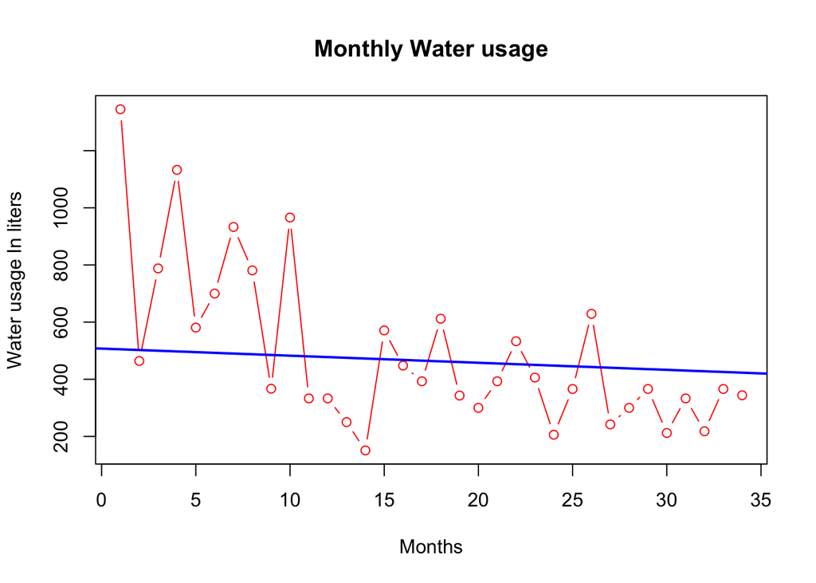

```r
plot(df.f$Avg.Daily.Water.Use.in.Liters,
     type = "b",
     main = "Monthly Water usage",
     xlab = "Months",
     ylab = "Water usage In liters",
     col = "Red")
trendline <- lm(Avg.Daily.Water.Use.in.Liters ~ Month, data = df.f)
abline(trendline, col = "blue", lwd = 2)  # Blue color, line width = 2
```

This is a plot of the time series data with the trend line. The trend line is decreasing indicating decrease in trend overtime.

## Running the model

```r
hw_model <- HoltWinters(water_ts)
```

The Model is produced.

## Plot of the Model with time series data

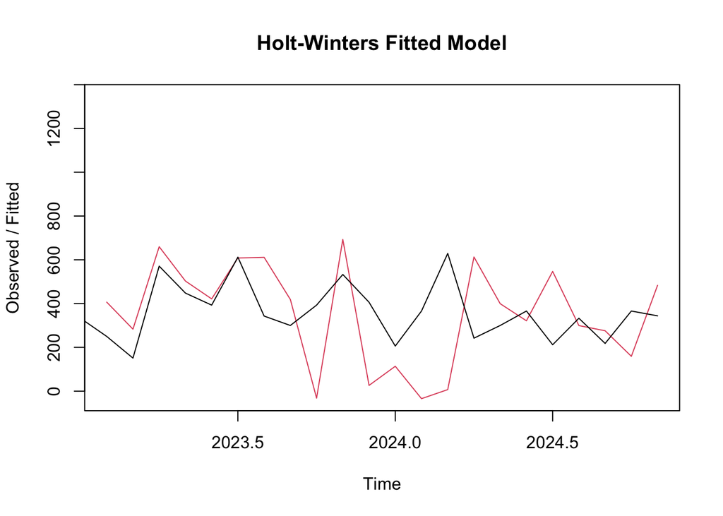

```r
# Plot the original time series along with the fitted values
plot(hw_model, main = "Holt-Winters Fitted Model")
```

The model is used to predict the values and these values are plotted along with the original time series data values to check for the accuracy.

# Section 2 - Forecasting

## Forecasting

```r
library(forecast)
forecast_horizon <- 2
hw_forecast <- forecast(hw_model, h = forecast_horizon, level = 95)

hw.forecast <- data.frame(hw_forecast)
```

We use the forecast function to forecast the Average Water Usage in Liters for the next two months which are December 2024 and January 2025. The forecast for December 2024 is 137.4968533 and the forecast interval of 95%, high:638.4834569 and low:-363.4897503. The forecast for January 2025 is -45.5401117 and the forecast interval of 95%, high:473.4172821 and low:-564.4975054.

## Plot of the forecast values

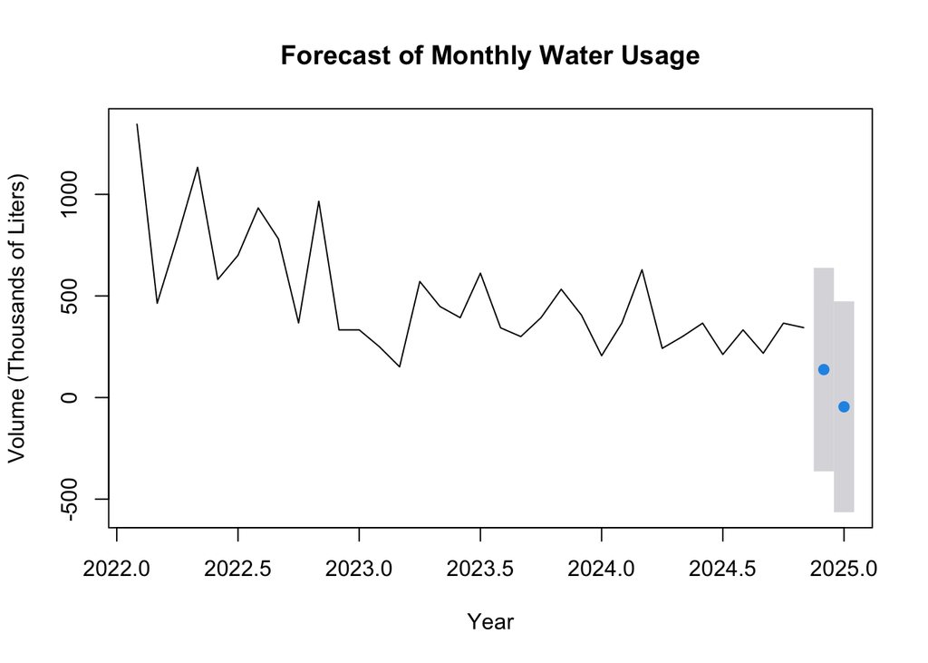

```r
# Plot the forecast
plot(hw_forecast,
     main = "Forecast of Monthly Water Usage",
     xlab = "Year",
     ylab = "Volume (Thousands of Liters)")
```